# Feature Engineering Ideas

Metodi Latinov

May 02, 2025

# 1 Feature Enginnering

## 1.1 1 BMI (Body Mass Index)

BMI is a measurement of a person’s leanness or corpulence based on their height and weight, and is intended to quantify tissue mass. It is widely used as a general indicator of whether a person has a healthy body weight for their height. Specifically, the value obtained from the calculation of BMI is used to categorize whether a person is underweight, normal weight, overweight, or obese depending on what range the value falls between.

$$BMI = weight (kg) / height² (meters)$$

```r
data <- data %>%
  mutate(
    # BMI Calculation
    bmi = Weight / (Height/100)^2
  )
```

### 1.1.1 BMI table for adults

This is the World Health Organization’s (WHO) recommended body weight based on BMI values for adults. It is used for both men and women, age 20 or older.

Classification BMI range - kg/m2

- 1 Severe Thinness < 16
- 2 Moderate Thinness 16 - 17
- 3 Mild Thinness 17 - 18.5
- 4 Normal 18.5 - 25
- 5 Overweight 25 - 30
- 6 Obese Class I 30 - 35
- 7 Obese Class II 35 - 40
- 8 Obese Class III > 40

```r
data <- data %>%
  mutate(

    # Classification BMI
    classification_BMI = case_when(
      bmi < 16 ~ "Severe Thinness",
      bmi >= 16 & bmi < 17 ~ "Moderate Thinness",
      bmi >= 17 & bmi < 18.5 ~ "Mild Thinness",
      bmi >= 18.5 & bmi < 25 ~ "Normal",
      bmi >= 25 & bmi < 30 ~ "Overweight",
      bmi >= 25 & bmi < 35 ~ "Obese_Class_I",
      bmi >= 35 & bmi < 40 ~ "Obese Class_II",
      bmi >= 40 ~ "Obese Class III",
      )
  )
```

## 1.2 BMI prime

BMI prime is the ratio of a person’s measured BMI to the upper limit of BMI that is considered “normal,” by institutions such as the WHO and the CDC. Though it may differ in some countries, such as those in Asia, this upper limit, which will be referred to as BMIupper is 25 kg/m2

The BMI prime formula is:
$$BMI_{prime} = \frac{BMI}{25}$$
Classification BMI Prime:

- 1 Severe Thinness < 0.64
- 2 Moderate Thinness 0.64 - 0.68
- 3 Mild Thinness 0.68 - 0.74
- 4 Normal 0.74 - 1
- 5 Overweight 1 1 - 1.2
- 6 Obese Class I 1.2- 1.4
- 7 Obese Class II 1.4 - 1.6
- 8 Obese Class III > 1.6

```r
data <- data %>%
  mutate(

    # The BMI prime calculation
    bmi_prime = bmi / 25,

    # Classification BMI Prime
    classification_BMI_Prime = case_when(
      bmi_prime < 0.64 ~ "Severe_Thinness_prime",
      bmi_prime >= 0.64 & bmi_prime < 0.68 ~ "Moderate_Thinness_prime",
      bmi_prime >= 0.68 & bmi_prime < 0.74 ~ "Mild_Thinness_prime",
      bmi_prime >= 0.74 & bmi_prime < 1 ~ "Normal_prime",
      bmi_prime >= 1 & bmi_prime < 1.2 ~ "Overweight_1_prime",
      bmi_prime >= 1.2 & bmi_prime < 1.4 ~ "Obese_Class_I_prime",
      bmi_prime >= 1.4 & bmi_prime < 1.6 ~ "Obese_Class_II_prime",
      bmi_prime >= 1.6 ~ "Obese_Class_III_prime"
    )
    )
```

## 1.3 Ponderal Index

The Ponderal Index (PI) is similar to BMI in that it measures the leanness or corpulence of a person based on their height and weight. The main difference between the PI and BMI is the cubing rather than squaring of the height in the formula (provided below). While BMI can be a useful tool when considering large populations, it is not reliable for determining leanness or corpulence in individuals. Although the PI suffers from similar considerations, the PI is more reliable for use with very tall or short individuals, while BMI tends to record uncharacteristically high or low body fat levels for those on the extreme ends of the height and weight spectrum.

The Ponderal Index formula is:

$$PI = \frac{\text{Mass (kg)}}{\text{Height (m)}^3}$$

Classification PI:

- 1 Severe Thinness < 9
- 2 Moderate Thinness 9 - 9.5
- 3 Mild Thinness 9.5 - 11
- 4 Normal 11 - 15
- 5 Overweight 1 15 - 17.5
- 6 Obese Class I 17.5 - 20.5
- 7 Obese Class II 20.5 - 23.5
- 8 Obese Class III > 23.5

```r
data <- data %>%
  mutate(

    # Ponderal Index
    ponderal_index = Weight / (Height/100)^3,

    # Classification PI
    classification_PI = case_when(
      ponderal_index < 9 ~ "Severe_Thinness_prime",
      ponderal_index >= 9 & ponderal_index < 9.5 ~ "Moderate_Thinness_pi",
      ponderal_index >= 9.5 & ponderal_index < 11 ~ "Mild_Thinness_pi",
      ponderal_index >= 11 & ponderal_index < 15 ~ "Normal_pi",
      ponderal_index >= 15 & ponderal_index < 17.5 ~ "Overweight_1_pi",
      ponderal_index >= 17.5 & ponderal_index < 20.5 ~ "Obese_Class_I_pi",
      ponderal_index >= 20.5 & ponderal_index < 23.5 ~ "Obese_Class_II_pi",
      ponderal_index >= 23.5 ~ "Obese_Class_III_prime"
    )
  )
```

## 1.4 BSA (Body Surface Area)

BSA is often used in clinical purposes over body weight because it is a more accurate indicator of metabolic mass (the body’s need for energy). Metabolic mass can be estimated using fat-free mass, where fat-free mass is all of a person’s body mass that does not include fat. This includes bones, tendons, inner organs, muscles, blood, nerves, and more. Since body fat is not metabolically active and fat-free mass excludes body fat, fat-free mass is a reasonable estimate of metabolic mass. BSA is represented in m2

Du Bois formula :

$${\displaystyle {BSA}=0.007184\times W^{0.425}\times H^{0.725}}$$

```r
data <- data %>%
  mutate(
    # Du Bois formula for BSA :
    bsa = 0.007184 * Weight^0.425 * Height^0.725
  )
```

## 1.5 Calories Burned By Heart Rate in Theory

The Keytel formula estimates calories burned per minute during exercise based on your heart rate, age, weight, and sex. It does not require HRmax. Instead, it uses your measured heart rate to calculate actual energy expenditure, making it useful for real-time or post-workout calorie estimates Only useful with a heart rate between 90 and 150

The Keytel formula for Woman :

$$\text{Calories} = \left( \frac{-20.4022 + (0.4472 \times HR) - (0.1263
\times W) + (0.074 \times A)}{4.184} \right) \times 60 \times T$$

The Keytel formula for Men :

$$\text{Calories} = \left( \frac{-55.0969 + (0.6309 \times HR) - (0.1988
\times W) + (0.2017 \times A)}{4.184} \right) \times 60 \times T$$
Where:
- $HR$ = average heart rate (beats per minute)
- $W$ = weight in kilograms
- $A$ = age in years
- $T$ = duration of exercise in hours

```r
data <- data %>%
  mutate(

    # The Keytel formula Burned By Heart Rate in Theory
    keytel_theoretical = case_when(
      Sex == "female" ~
        ((-20.4022 + (0.4472 * Heart_Rate) -
          (0.1263 * Weight) + (0.074 * Age)) / 4.184) * Duration,

      Sex == "male" ~
        ((-55.0969 + (0.6309 * Heart_Rate) -
          (0.1988 * Weight) + (0.2017 * Age)) / 4.184) * Duration
    )
  )
```

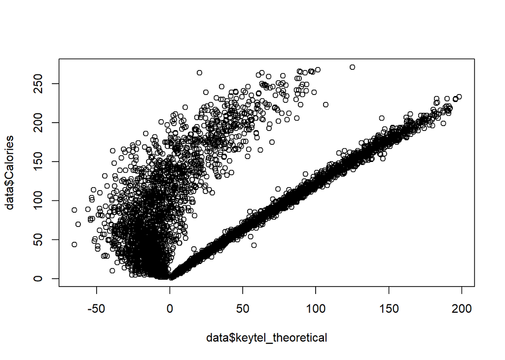

## 1.6 VO2 max

VO2 max is the maximum amount of oxygen that an individual can utilize during intense or maximal exercise

Heart Rate-based VO2max Estimation Formula:

$$\text{VO2max} = 15 \times \left( \frac{\text{HRmax}}{\text{Resting HR}}
\right)$$
Where:

- **HRmax** is estimated as :

$$\text{HRmax (beats/minute)} = 208 - (0.7 \times \text{Age})$$
- **Resting HR** is the resting heart rate measured at rest (Assumtions) ~ 80bpm.

This method uses Heart Rate (HR) and Age to estimate VO2max. It’s based on the assumption that higher heart rates during exercise indicate lower VO2max.

```r
data <- data %>%
  mutate(

    # **HRmax** is estimated as
    hr_max = 208 - (0.7 * Age),

    # Heart Rate-based VO2max Estimation :
    vo2_max = 15 * (hr_max / 80)
  )
```

## 1.7 Calories burned formulas based on a metabolic equation model using Vo2max

```r
data <- data %>%
  mutate(

    # Calories burned formulas based on a metabolic equation model using Vo2max:
    metabolic_vo2_cal = case_when(
      Sex == "male" ~
        ((-95.7735 + (0.634 * Heart_Rate) + (0.404 * vo2_max) +
          (0.394 * Weight) + (0.271 * Age)) / 4.184) * Duration,
      Sex == "female" ~
        ((-59.3954 + (0.634 * Heart_Rate) + (0.380 * vo2_max ) +
          (0.103 * Weight) + (0.274 * Age)) / 4.184) * Duration
    )
  )
```

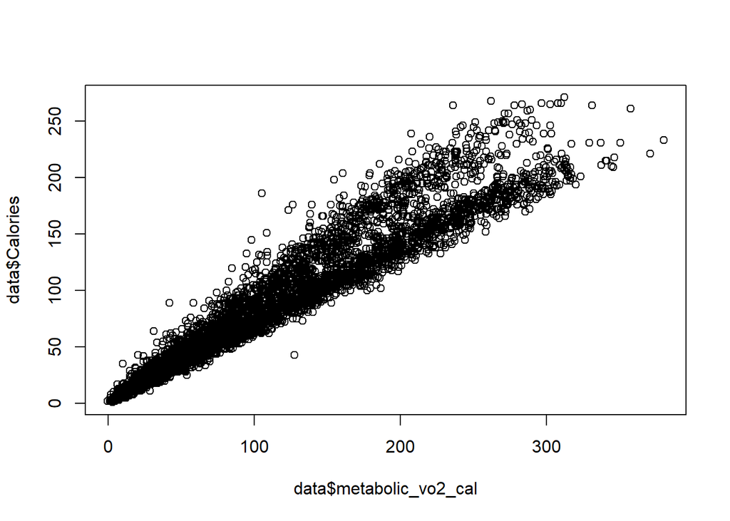

## 1.8 The metabolic equivalent of task (MET)

The Metabolic Equivalent of Task is a measure that assesses an individual’s energy expenditure during various physical activities. It expresses the energy cost of physical activities relative to energy expended at rest. One MET corresponds to an energy expenditure of 1 kcal/kg/hour or an oxygen uptake of 3.5 ml/kg/min

$$\text{MET} = \frac{\text{VO}_2 \ (\text{ml/kg/min})}{3.5}$$
To estimate the oxygen consumption at a given effort level using Vo2max:

$$\text{VO}_2 = \text{VO}_{2\text{max}} \times \%\text{Effort}$$
The percentage of effort during exercise can be estimated using the heart rate reserve formula:

$$\%\text{Effort} = \frac{\text{HR}_{\text{exercise}} -
\text{HR}_{\text{rest}}}{\text{HR}_{\text{max}} -
\text{HR}_{\text{rest}}}$$
The calories burned per minute can be estimated with the following formula:

$$\text{Calories Burned (per minute)} = \text{MET} \times \text{Weight
(kg)} \times 0.0175$$

To calculate the **total calories burned** in a workout session:

$$\text{Total Calories} = \text{MET} \times \text{Weight (kg)} \times
0.0175 \times \text{Duration (min)}$$

```r
data <- data %>%
  mutate(

    # The percentage of effort during exercise can be estimated using the heart rate reserve :
    effort = (Heart_Rate - 80) / (hr_max - 80),

    # To estimate the oxygen consumption at a given effort level using Vo2max
    vo2 = vo2_max * effort,

    # Calculate Metabolic Equivalent of Task
    met = vo2 / 3.5,

    # Calculate the total calories burned in a workout session
    calories_met_estimation = met * Weight * 0.0175 * Duration
  )
```

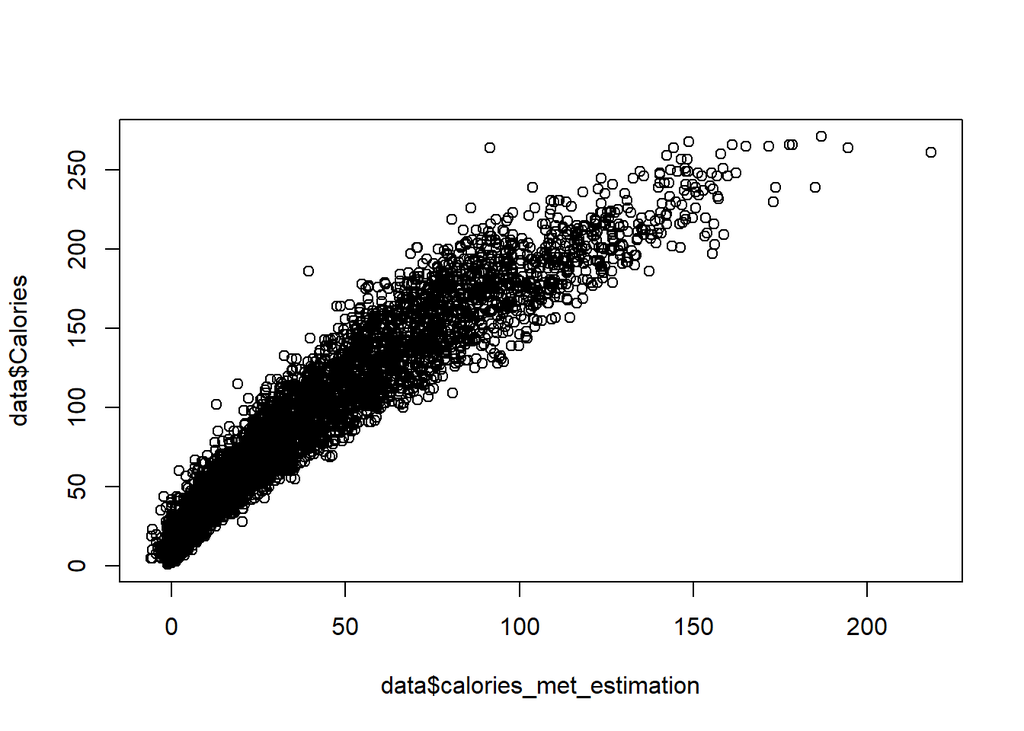

## 1.9 Basic Thermodynamics

During exercise, the human body is only about **20–25% mechanically efficient**, meaning that **75–80% of energy is lost as heat**. The energy expenditure (calories burned) based on temperature rise can be estimated as:

$$\text{Calories} = \frac{\Delta T \times m \times c}{\text{Efficiency}}$$
Where:

- $\Delta T$ = Change in core temperature (°C)
- $m$ = Body mass (kg)
- $c$ = Specific heat capacity of the human body (≈ 3.47 kJ/kg/°C or 0.83 kcal/kg/°C)
- $\text{Efficiency}$ = Mechanical efficiency, typically between 0.20 and 0.25

Limitations:

Assumes perfect heat retention (no sweating/convection).

Doesn’t separate exercise heat from environmental factors.

```r
data <- data %>%
  mutate(

    # Change in core temperature (°C)
    delta_t = Body_Temp - 37,

    # Ccalories burned based on temperature rise can be estimated as:
    cal_thermodynamics = (delta_t * Weight * 0.83) / 0.25
  )
```

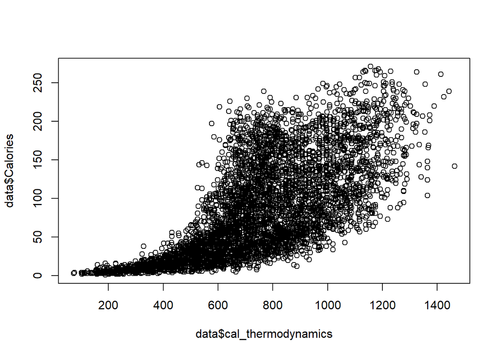

## 1.10 Integrating Metabolic Rate

Core body temperature correlates with metabolic rate. The **Q10 effect** suggests that metabolism approximately **doubles for every 10°C increase in temperature**. This can be used to estimate calorie burn during elevated core temperatures:

$$\text{Calories per minute} = \text{BMR}_{\text{adjusted}} \times
2^{\frac{T_{\text{core}} - 37}{10}}$$

Where:

- $\text{BMR}_{\text{adjusted}}$ = Basal Metabolic Rate in kcal/min  
  (e.g., ~1 kcal/min for a 70 kg person)
- $T_{\text{core}}$ = Core body temperature in °C

Calculate BMR (Mifflin-St Jeor Equation) with the formula :

$$\text{Exercise Calories/min} = \text{BMR} \times
\left(2^{(T_{\text{core}} - 37)/10} - 1\right)$$

```r
data <- data %>%
  mutate(

    # Calculate BMR (Mifflin-St Jeor Equation)
    bmr = case_when(
      Sex == "male" ~ (10 * Weight) + (0.25 * Height) - (5 * Age) + 5,
      Sex == "female" ~ (10 * Weight) + (0.25 * Height) - (5 * Age) - 161),

    # Q10 Effect to Exercise with
   calculate_metabolic_cals =  bmr * (2^((Body_Temp - 37)/10) - 1) * Duration
  )
```

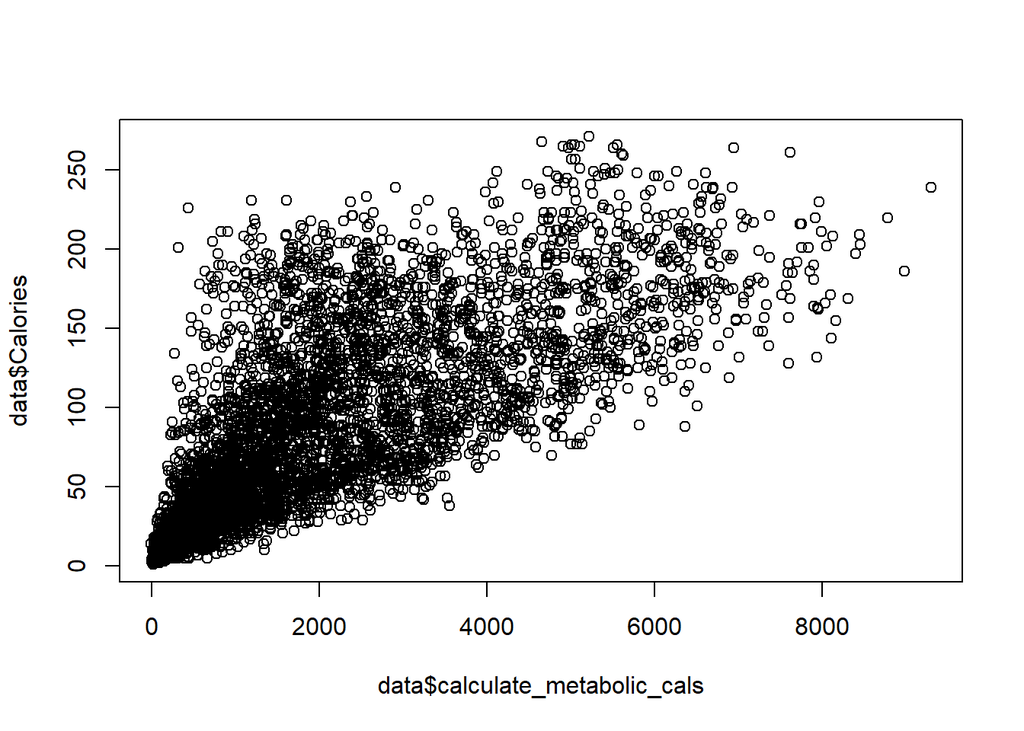

## 1.11 FFMI-Weighted METs

The formula to estimate calories burned from Adjusted MET with FFMI is:

$$\text{Calories} = \text{Adjusted MET} \times \text{Weight (kg)} \times
\text{Duration (hours)}$$

The Adjusted MET is calculated as:

$$\text{Adjusted MET} = \text{Base MET} \times \left(
\frac{18}{\text{FFMI}} \right)$$

The formula for FFMI, adjusted for height, is:

$$\text{FFMI} = \frac{\text{Lean Mass (kg)}}{[\text{Height (m)}]^2} + 6.1
\times (1.8 - \text{Height (m)})$$

Lean Mass (Fat-Free Mass) is calculated as:

$$\text{Lean Mass (kg)} = \text{Weight (kg)} \times (1 -
\frac{\text{BFP}}{100})$$

Body Fat Percentage (BFP) Formulas from BMI :

For Adult Males:

$$\text{BFPmale} = 1.20 \times \text{BMI} + 0.23 \times \text{Age} - 16.2$$

For Adult Females:

$$\text{BFPfemale} = 1.20 \times \text{BMI} + 0.23 \times \text{Age} - 5.4$$

```r
data <- data %>%
  mutate(

    # Body Fat Percentage is calculated as
    bfp = case_when(
      Sex == "male" ~ 1.20 * bmi + 0.23 * Age - 16.2,
      Sex == "female" ~ 1.20 * bmi + 0.23 * Age - 5.4
    ),

    # Lean Mass (Fat-Free Mass) is calculated as
    lean_mass_kg = Weight * (1 - (bfp / 100)),

    # FFMI adjusted for height, is calculated as
    ffmi = lean_mass_kg / ((Height/100)^2) + 6.1 * (1.8 - (Height/100)),

    # Adjusted MET is calculated as
    met_ffmi_adjusted = met * (18 / ffmi),

    # Estimate calories burned from Adjusted MET with FFMI
    calories_met_ffmi_adjusted = met_ffmi_adjusted * Weight * (Duration / 60)

  )
```

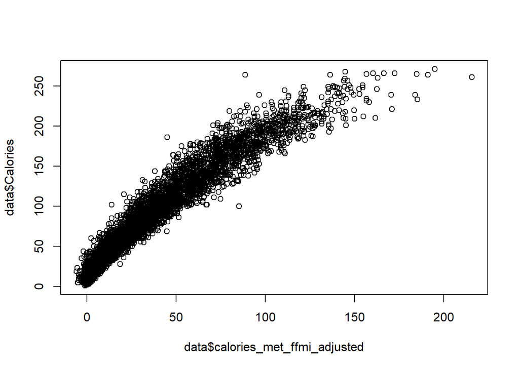